# Problem Set 1

Behavioral Economics, Boston College

Sherry Peng TIAN

Sep 25, Fall 2019

*The assignment is worth **100 points**. There are **25 questions**. You should have the following packages installed:*

```r
rm(list = ls()) # Clear environment
library(tidyverse)
library(cowplot)
library(sandwich)
library(lmtest)
```

In this problem set you will summarize the paper [“Individual Behavior and Group Membership: Comment”](https://www.aeaweb.org/articles?id=10.1257/aer.99.5.2247) (Sutter, AER 2009) and recreate its findings.

# 1 Big picture

**1. What is the main question asked in this paper?**

The main question is why differences between team decisions and individual decisions occur; the goal is to relate the effects of group membership on individual behavior to team decision making.

**2. Summarize the experiment methodology. Make sure to explain: a) how the investment task works, including an explanation of the payoff function to a subject, and b) why the task is “nonstrategic”.**

a). The investment task asks the students to investment with an endowment payment of 100 euro-cents in a total of 9 rounds, resulting a 1/3 probability of 100+2.5X payoff and a 2/3 probability of 100-X payoff. b). To decide a task is strategic whether or not depends on whether one party’s actions will influence the other party’s actions. Here, this experiment is nonstrategic because the nine rounds are independent of each other and the investment decisions are only made once, either by the individual or individuals as a group.

**3. Explain the differences between each treatment.**

1). INDIVIDUALS (n=64) and TEAMS (n=85/3=28) 2). PAY-COMM (n=54) - one individual making decisions on behalf of the team for 3 rounds, and MESSAGE (n=72) - but sending nonbinding messages.

**4. Summarize the main results of the paper.**

It turned out making decisions as a group has some effect on individual decision making because of the decisio procedures of sharing the same gain or loss.

**5. Why are these results valuable? What have we learned? Motivate your discussion with a real-world example.**

a). The effects of salient group memebership on individual behavior prevail also in a nonstrategic task that has no outgroup. b). team decision making has the same effects as salient group membership on individual decisions. c). the experience of team decision making also affects individual behavior. Therefore, both salient group membership and team decision making have largely the SAME effects on individual behavior. Real-world example: highly related to behavioral finance, when people are investing in the stock market, not precisely in a group but might be affected by the surroundings, like side rumors.

# 2 Replication

## 2.1 Set-up

**6. Import the data into a dataframe object called `df`, then convert all the column names to lowercase.**

```r
df <- read_csv("sutterexperiment.csv")
old.names <- colnames(df)
new.names <- tolower(old.names)
colnames(df) <- new.names
rm(new.names, old.names)

df$treatment <- tolower(df$treatment)
```

**7. Create a variable called “uniquesubject” that contains unique subject identifiers. Use [`mutate()`](https://dplyr.tidyverse.org/reference/mutate.html) and [`paste()`](https://stat.ethz.ch/R-manual/R-devel/library/base/html/paste.html). (Hint: what variables do you need to “paste” together to ensure each subject is uniquely identified?)**

```r
df <- df %>%
  mutate(uniquesubject = paste(session, treatment, subject, sep = "_"))
```

**8. Similarly, create a variable called “uniqueteam” that contains unique team identifiers. Do it so that the variable has the same values as `subjectid` for all subjects in the INDIVIDUALS treatment.**

**9. Create a new dataframe called `df_narrow` that converts `df` to “narrow form” (also known as “long form”) using [`gather()`](https://tidyr.tidyverse.org/reference/gather.html) and arranges observations by `session, subject, treatment, team` using [`arrange()`](https://dplyr.tidyverse.org/reference/arrange.html).**

```r
df <- df %>%
  mutate(uniqueteam = paste(session, team, sep = "_"))
df <- df %>% mutate(uniqueteam = ifelse(treatment == "individuals", uniquesubject, uniqueteam))

df_narrow <- df %>%
  gather("round", "investment", -c(session, subject, treatment, team, uniquesubject, uniqueteam)) %>%
  arrange(session, subject, treatment, team)

# df %>% gather("key", "value", x, y, z) is equivalent to df %>% pivot_longer(c(x, y, z), names_to = "key", values_to = "value")
```

**10. Notice that all the values for the variable `round` are prepended with “r”. Remove it using [`gsub()`](https://astrostatistics.psu.edu/su07/R/html/base/html/grep.html).**

```r
#df_narrow <- read_csv("sutterexperiment_long.csv")
df_narrow$round <- gsub("r", "", df_narrow$round)
```

*Note: After questions 7-9 your dataframe `df_narrow` should look like `sutterexperiment_long.csv`.*

## 2.2 Summary table and plot

**11. Use `df_narrow` a summary table of mean outcomes and standard deviations by treatment. (Do not create a separate dataframe.)**

```r
df_narrow %>%
  group_by(treatment) %>%
  select(investment) %>%
  summarise_all(funs(mean, sd))
```

```
## # A tibble: 5 x 3
##   treatment    mean    sd
##   <chr>       <dbl> <dbl>
## 1 individuals  39.4  32.4
## 2 message      61.4  36.4
## 3 mixed        50.0  36.4
## 4 pay-comm     50.3  32.7
## 5 teams        55.7  34.8
```

**12. Create a bar plot that displays the mean of each treatment and error bars that display the standard errors of the means. Color each bar gray. Make sure to title the axes and the plot. The subtitle should tell the reader the error bars display the standard error of the mean. Use `theme_classic()` to display the plot.**

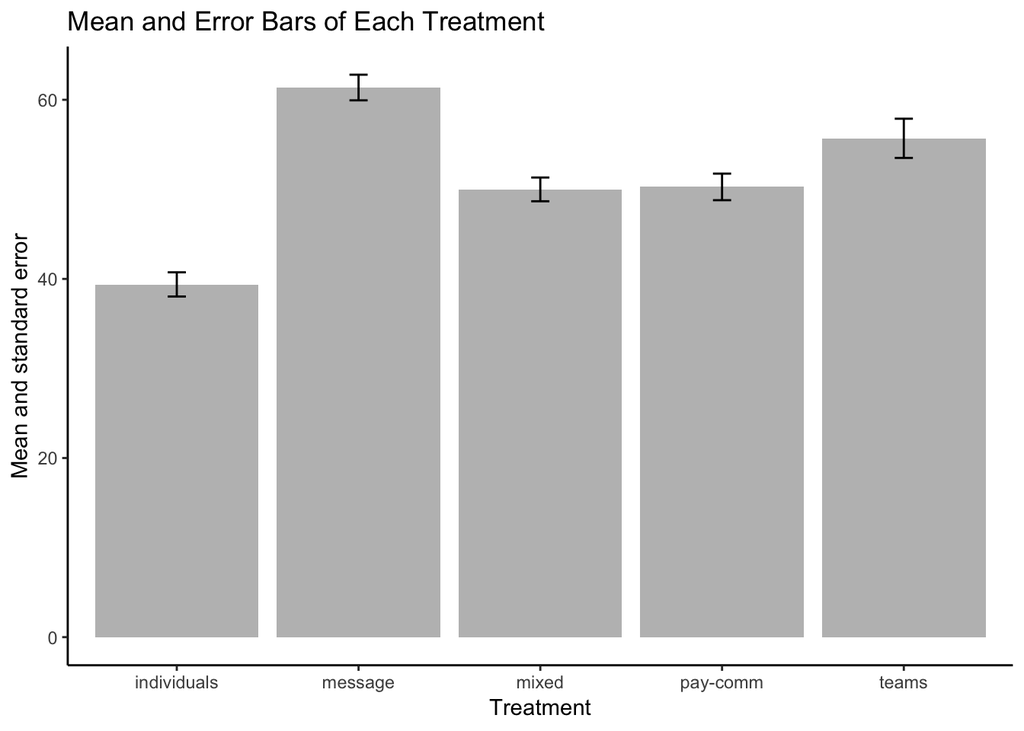

```r
df_narrow %>%
  group_by(treatment) %>%
  ggplot(., aes(treatment, investment)) +
  stat_summary(fun.y = mean, geom = "bar", fill="grey") +
  stat_summary(fun.data = mean_se, geom = "errorbar", width=0.1) +
  labs(y = "Mean and standard error", x = "Treatment", title = "Mean and Error Bars of Each Treatment") +
  theme_classic()
```

## 2.3 Replicating Figures 1-3

Use `df_narrow` to recreate Figures 1-3. Your code should proceed as follows:

- begin with the dataframe
- then filter out observations you don’t need for the plot at hand
- then group observations by treatment and round
- then calculate the mean by treatment and round
- then plot.

Each plot should be appropriately titled and axes should be appropriately labeled. Make sure the legend displays what you think it should. Use `theme_classic()` to display the plots.

**13. Recreate Figure 1 and assign it to an object `p1`.**

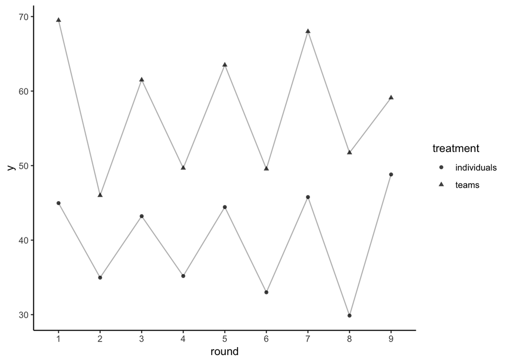

```r
#table1 <- df_narrow %>%  filter(treatment == c("individuals", "teams"))%>%  group_by(round, treatment) %>%  summarise(y = mean(investment))
#fig1 <- ggplot(table1, aes(round, y, group = treatment)) + geom_line(color = "grey") + geom_point(alpha = 0.75, aes(shape = treatment))

fig1 <- df_narrow %>%
  select(treatment, round, investment) %>%
  filter(treatment == c("individuals", "teams")) %>%
  group_by(round, treatment) %>%
  summarise(y = mean(investment)) %>%
  ggplot(., aes(round, y)) +
  geom_line(aes(group = treatment), color = "grey") +
  geom_point(alpha=0.75, aes(shape = treatment)) +
  labs(size = "Round") +
  theme_classic()

fig1
```

**14. Recreate Figure 2 and assign it to an object `p2`.**

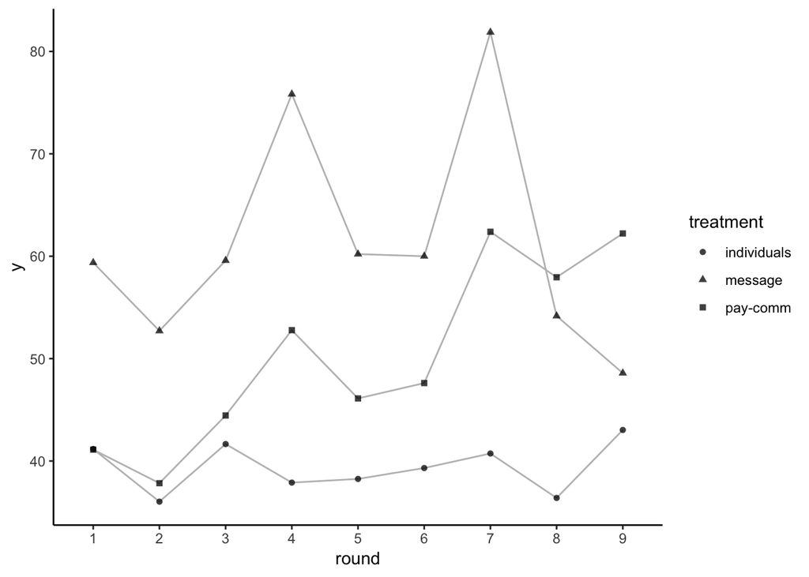

```r
table2.1 <- df_narrow %>%
  filter(treatment == "individuals") %>%
  group_by(round, treatment) %>%
  summarise(y = mean(investment))
table2.2 <- df_narrow %>%
  filter(treatment == "pay-comm") %>%
  group_by(round, treatment) %>%
  summarise(y = mean(investment))
table2.3 <- df_narrow %>%
  filter(treatment == "message") %>%
  group_by(round, treatment) %>%
  summarise(y = mean(investment))
table2 <- rbind(table2.1, table2.2)
table2 <- rbind(table2, table2.3)

fig2 <- ggplot(table2, aes(round, y, group = treatment)) + geom_line(color = "grey") + geom_point(alpha = 0.75, aes(shape = treatment)) + labs(size = "Round") + theme_classic()
fig2
```

**15. Recreate Figure 3 and assign it to an object `p3`.**

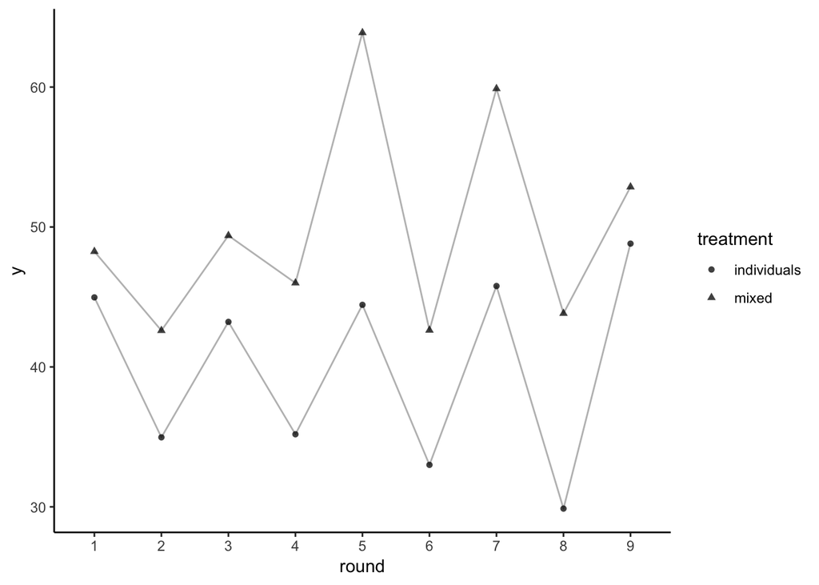

```r
fig3 <- df_narrow %>%
  select(treatment, round, investment) %>%
  filter(treatment == c("individuals", "mixed")) %>%
  group_by(round, treatment) %>%
  summarise(y = mean(investment)) %>%
  ggplot(., aes(round, y)) +
  geom_line(aes(group = treatment), color = "grey") +
  geom_point(alpha=0.75, aes(shape = treatment)) +
  labs(size = "Round") +
  theme_classic()
fig3
```

LDG: Good job. I would use colors or different linetypes to better distinguish treatments. And you can simplify your code. For example, the last image:

[figure not shown]

```r
df_narrow %>%
  filter(treatment == "INDIVIDUALS" | treatment == "MIXED") %>%
  group_by(treatment,round) %>%
  summarize(meanvalue = mean(investment)) %>%
    ggplot(., aes(round, meanvalue, group=treatment, color=treatment)) +
    geom_point() +
    geom_line() +
    ylim(20,100) +
    theme_classic()
```

**16. Use `cowplot()` to combine the three plots into one figure. There should be one row and three columns and each plot should be labeled with a letter (first one “a”, second one “b”, third on “c”).**

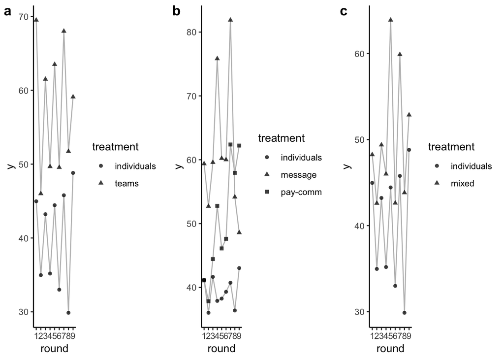

```r
rm(table1, table2.1, table2.2, table2.3, table2, table3)
plot_grid(fig1, fig2, fig3,
  labels = c('a', 'b', 'c'),
  nrow = 1)
```

# 3 Inference

**17. The paper uses Wilcoxon or Man-Whitney U-tests to check for average treatment effects. This test is similar to a t-test but with some key differences. Summarize these differences. Make sure to compare and contrast and the null hypotheses of each test.**

All test on the median $\theta$. The difference between the Mann-Whitney U and the Wilcoxon tests relates to the design of the experiment. If your experiment has a repeated measures or matched participants design then the Wilcoxon test is used to analyse your data. If your experiment has an independent measures design then the Mann-Whitney U test is used to analyse your data.

The differences between Wilcoxon or Man-Whitney U-tests and t-test are the u-tests compare differences between two independent groups when the dependent variable is either ordinal or continuous, but not normally distributed; therefore, it is considered the nonparametric alternative to the independent t-test.

**18. When conducting these tests, the authors first calculate the average decision of each subject across rounds. This implies the authors do not want to treat subject decisions as independent across rounds. Why?** Because after each round, the inviduals or the team would be notified of their payoffs, so the outcome might somehow influence their next decision and move.

**19. Create a dataframe frame of subject/team averages across treatments. Call this dataframe `df_team_avg`. It should have 162 rows.**

```r
df_team_avg <- df_narrow %>%
  group_by(treatment, uniqueteam) %>%
  summarise(mean(investment))

# should be get 99 rows
df_narrow %>%
  group_by(uniqueteam) %>%
  summarise(mean(investment))
```

```
## # A tibble: 99 x 2
##    uniqueteam      `mean(investment)`
##    <chr>                        <dbl>
##  1 1_1                          54.2
##  2 1_2                          33.9
##  3 1_3                          57.0
##  4 1_4                          45.8
##  5 1_5                          53.8
##  6 1_6                          46.1
##  7 1_7                          41.7
##  8 1_8                          55.8
##  9 1_9                          22.8
## 10 1_individuals_1               2.22
## # … with 89 more rows
```

**20. Recreate Result 1 (significant difference between treatments INDIVIDUALS and TEAMS, $N=92$).**

```r
ppl <- df_team_avg$`mean(investment)`[which(df_team_avg == "individuals")]
team <- df_team_avg$`mean(investment)`[which(df_team_avg == "teams")]

wilcox.test(ppl, team, var.equal=F, paired = F)
```

```
##
##  Wilcoxon rank sum test with continuity correction
##
## data:  ppl and team
## W = 616.5, p-value = 0.01789
## alternative hypothesis: true location shift is not equal to 0
```

**21. Recreate Result 2 (significant difference between INDIVIDUALS and PAY-COMM, $N=82$; significant difference between PAY-COMM and MESSAGE, $N=42$; no signfiicant difference between TEAMS and MESSAGE, $N=52$; no significant difference between TEAMS and PAY-COMM, $N=46$).**

```r
pay <- df_team_avg$`mean(investment)`[which(df_team_avg == "pay-comm")]
mes <- df_team_avg$`mean(investment)`[which(df_team_avg == "message")]


wilcox.test(ppl, pay, var.equal = F, paired = F)
```

```
##
##  Wilcoxon rank sum test with continuity correction
##
## data:  ppl and pay
## W = 360, p-value = 0.01576
## alternative hypothesis: true location shift is not equal to 0
```

```r
wilcox.test(pay, mes, var.equal = F, paired = F)   # 0.06903
```

```
##
##  Wilcoxon rank sum test with continuity correction
##
## data:  pay and mes
## W = 144, p-value = 0.06903
## alternative hypothesis: true location shift is not equal to 0
```

```r
wilcox.test(team, mes, var.equal = F, paired = F)
```

```
##
##  Wilcoxon rank sum test with continuity correction
##
## data:  team and mes
## W = 288, p-value = 0.3831
## alternative hypothesis: true location shift is not equal to 0
```

```r
wilcox.test(team, pay, var.equal = F, paired = F)
```

```
##
##  Wilcoxon rank sum test with continuity correction
##
## data:  team and pay
## W = 265.5, p-value = 0.7697
## alternative hypothesis: true location shift is not equal to 0
```

Correction!!!

```r
df_team_avg %>%
  filter(treatment == "message" | treatment == "pay-comm") %>%
  wilcox.test(`mean(investment)` ~ treatment, .)
```

```
##
##  Wilcoxon rank sum test with continuity correction
##
## data:  mean(investment) by treatment
## W = 288, p-value = 0.06903
## alternative hypothesis: true location shift is not equal to 0
```

```r
df_team_avg %>%
  filter(treatment == "teams" | treatment == "message") %>%
  wilcox.test(`mean(investment)` ~ treatment, .)
```

```
##
##  Wilcoxon rank sum test with continuity correction
##
## data:  mean(investment) by treatment
## W = 384, p-value = 0.3831
## alternative hypothesis: true location shift is not equal to 0
```

**22. Use `df_narrow` to run the following regression: $y_{it} = \beta_0 + \beta_1T_i + \varepsilon_{it}$ where $y_{it}$ is the decision of subject $i$ in round $t$ and $T_i$ is her treatment. INDIVIDUALS should be the base treatment. Assign the regression to object `m` and then print the output using `summary(m)`.**

```r
#df_narrow <- cbind(df_narrow, dummy(df_narrow$treatment, sep = "_"))

m <- lm(investment ~ treatment, data = df_narrow)
summary(m)
```

```
##
## Call:
## lm(formula = investment ~ treatment, data = df_narrow)
##
## Residuals:
##     Min      1Q  Median      3Q     Max
## -61.370 -29.385  -0.542  38.630  60.615
##
## Coefficients:
##                   Estimate Std. Error t value Pr(>|t|)
## (Intercept)         39.385      1.451  27.152  < 2e-16 ***
## treatmentmessage    21.985      1.994  11.028  < 2e-16 ***
## treatmentmixed      10.609      1.925   5.510 3.92e-08 ***
## treatmentpay-comm   10.886      2.144   5.077 4.09e-07 ***
## treatmentteams      16.313      2.629   6.204 6.34e-10 ***
## ---
## Signif. codes:  0 '***' 0.001 '**' 0.01 '*' 0.05 '.' 0.1 ' ' 1
##
## Residual standard error: 34.81 on 2713 degrees of freedom
## Multiple R-squared:  0.04473,    Adjusted R-squared:  0.04333
## F-statistic: 31.76 on 4 and 2713 DF,  p-value: < 2.2e-16
```

**23. Interpret the results. (Hint: what is the hypothesis test on each coefficient?)**

Null Hypothesis:
$$H_0$$
: the two independent groups are homogeneous and have the same distribution, so the distribution shift is 0. Alternatively Hypothesis: the distribution shift is not 0. But the
$$H_0$$
for multiple regression: there is no correlation within the parameters;
$$D_0 = D_1 = D_2 = D_3 = D_4$$
.
The alternative hypothesis is that there is high correlation with parameters. Because we reject the null hypothesis that they don’t have the same distribution, the independent groups are not from the population, meaning the treatments have some effect on individuals’ investment decision-makings. Since all distributions are not normally distributed, the median rather than the mean is used for evaluation. With the regression results, all coefficients are statiscally significant at nearly 0.001 level.

**24. Now cluster the standard errors at the subject level. First create a new variance-covariance matrix called `vcov_subjectid`, then pass it to [`coeftest()`](https://www.rdocumentation.org/packages/lmtest/versions/0.9-37/topics/coeftest) to calculate the new standard errors, t-statistics and p-values.**

```r
vcov_subjectid <- sandwich::vcovCL(m, cluster = df_narrow$uniquesubject)
lmtest::coeftest(m, vcov_subjectid)
```

```
##
## t test of coefficients:
##
##                   Estimate Std. Error t value  Pr(>|t|)
## (Intercept)        39.3854     2.7143 14.5102 < 2.2e-16 ***
## treatmentmessage   21.9850     3.5871  6.1288 1.014e-09 ***
## treatmentmixed     10.6093     3.9640  2.6764 0.0074866 **
## treatmentpay-comm  10.8862     3.2891  3.3097 0.0009461 ***
## treatmentteams     16.3130     5.9967  2.7203 0.0065636 **
## ---
## Signif. codes:  0 '***' 0.001 '**' 0.01 '*' 0.05 '.' 0.1 ' ' 1
```

**25. Why bother clustering standard errors?**